# Constructing identity analysis

Colin Tredoux

THis document records some work complementing that carried out by Foud and VIAPPL team - constructing identity document.

# Preliminaries

Load some libraries

```r
library(pacman)
devtools::install_github('jtleek/slipper'); library(slipper)
p_load(tidyverse, psych, lavaan, lavaan.survey, haven, magrittr, nlme,
      stringr, janitor)
```

# Load the data

[output not shown]

Total cases matches that set down by Fouad in the document.

We need to identify the variables, we do this from the file “Apr17 untrimmed output inequality.txt” which we find in the Dropbox. This tells us the vars for the unequal groups data file.

This tells us that the clustering structure used was gameno, with grouping factor = condition.

The variables we need are IGF, OGG (OA in the article), rich (status, I think), gameno, ID (pre-id), pID (post-id), deltatokens (I assume the diff between beginning and end of game).

Let’s try and construct Fig 1 in the MS

# Fig 1

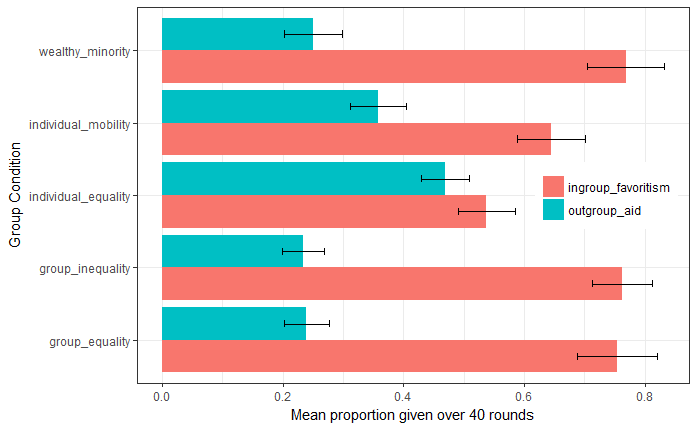

```r
mns <- id_all.dat %>%
    select(group_condition, ingroup_favoritism:outgroup_aid) %>%
    gather(key = dv, value = amt_given, ingroup_favoritism:outgroup_aid) %>%
    group_by(group_condition, dv) %>%
    summarise(mean=mean(amt_given),
              sd = sd(amt_given),
              n = n(),
              ci = (sd/sqrt(n))*1.96)
ggplot(mns, aes(x = group_condition, y = mean, fill = dv))  +
    geom_bar(position=position_dodge(), stat="identity") +
    geom_errorbar(aes(ymin=mean-ci, ymax=mean+ci),
                  width=.2,                    # Width of the error bars
                  position=position_dodge(.9)) +
    coord_flip() +
    theme_bw() +
    labs(x = "Group Condition", y = "Mean proportion given over 40 rounds") +
    theme(legend.title = element_blank(),
          legend.position = c(0.85,0.5))
ggsave("Figure_group_by_giving.pdf")
```

OK, lets try Figure 2 now

# Fig2

```r
# Build dataframe that contains standard deviations for conditions
# on Token change and let's bootstrap that a few times to get CIs
id_all.dat %>%
    group_by(group_condition) %>%
    summarise(sd = sd(delta_tokens, na.rm = T)/10)
```

| group_condition | sd |
| --- | --- |
| group_equality | 0.4297991 |
| group_inequality | 1.0430724 |
| individual_equality | 0.6957011 |
| individual_mobility | 1.0496753 |
| wealthy_minority | 1.3638182 |

```r
id_all.dat %>%
    select(group_condition, delta_tokens, uid) %>%
    spread(key = group_condition, value = delta_tokens) %>%
    select(-uid) -> x
x %>% summarise_all(funs(sd),na.rm = T)  -> z
x %>% slipper_ci(sd(group_equality, na.rm = T),B=1000) -> group_equality
x %>% slipper_ci(sd(group_inequality, na.rm = T),B=1000) -> group_inequality
x %>% slipper_ci(sd(individual_equality, na.rm = T),B=1000) -> individual_equality
x %>% slipper_ci(sd(individual_mobility, na.rm = T),B=1000) -> individual_mobility
x %>% slipper_ci(sd(wealthy_minority, na.rm = T),B=1000) -> wealthy_minority
group_boot_cis <- full_join(group_equality, group_inequality) %>%
    full_join(individual_equality) %>% full_join(individual_mobility) %>%
    full_join(wealthy_minority)
```

[output not shown]

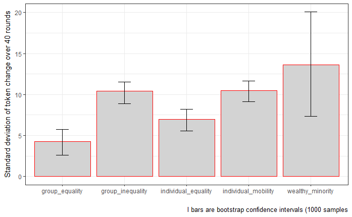

```r
group_boot_cis$group_condition <- c("group_equality", "group_inequality",
                                    "individual_equality", "individual_mobility",
                                    "wealthy_minority")
group_boot_cis$Standard_deviation <- t(z)
rm(x, group_equality, group_inequality, individual_equality, individual_mobility,
   wealthy_minority, z)
ggplot(group_boot_cis, aes(x = group_condition, y = Standard_deviation))  +
    geom_bar(position=position_dodge(), stat="identity", color="red",
             fill = "light grey") +
    geom_errorbar(aes(ymin=ci_low, ymax=ci_high),
                  width=.2,                    # Width of the error bars
                  position=position_dodge(.9)) +
    # coord_flip() +
    theme_bw() +
    labs(x = "",
         y = "Standard deviation of token change over 40 rounds",
         caption = "I bars are bootstrap confidence intervals (1000 samples")
ggsave("Figure_group_by_sd_token.pdf")
```

Now let’s test the sds to see if they differ. We try the Fligner-Killeen test

# Cf Standard deviations

```r
id_all.dat$group_condition <- factor(id_all.dat$group_condition)
fligner.test(delta_tokens ~ group_condition, data=id_all.dat)
```

```
    Fligner-Killeen test of homogeneity of variances

data:  delta_tokens by group_condition
Fligner-Killeen:med chi-squared = 49.988, df = 4, p-value =
3.632e-10
```

```r
(data=id_all.dat %>% filter(group_condition == "group_equality" |
                            group_condition == "group_inequality") %$%
                            fligner.test(delta_tokens ~ group_condition))
```

```
    Fligner-Killeen test of homogeneity of variances

data:  delta_tokens by group_condition
Fligner-Killeen:med chi-squared = 37.788, df = 1, p-value =
7.888e-10
```

```r
(data=id_all.dat %>% filter(group_condition == "group_equality" |
                            group_condition == "individual_equality") %$%
                            fligner.test(delta_tokens ~ group_condition))
```

```
    Fligner-Killeen test of homogeneity of variances

data:  delta_tokens by group_condition
Fligner-Killeen:med chi-squared = 12.758, df = 1, p-value =
0.0003544
```

```r
(data=id_all.dat %>% filter(group_condition == "group_equality" |
                            group_condition == "individual_mobility") %$%
                            fligner.test(delta_tokens ~ group_condition))
```

```
    Fligner-Killeen test of homogeneity of variances

data:  delta_tokens by group_condition
Fligner-Killeen:med chi-squared = 35.6, df = 1, p-value =
2.422e-09
```

```r
(data=id_all.dat %>% filter(group_condition == "group_equality" |
                            group_condition == "wealthy_minority") %$%
                            fligner.test(delta_tokens ~ group_condition))
```

```
    Fligner-Killeen test of homogeneity of variances

data:  delta_tokens by group_condition
Fligner-Killeen:med chi-squared = 16.517, df = 1, p-value =
4.822e-05
```

```r
(data=id_all.dat %>% filter(group_condition == "group_inequality" |
                            group_condition == "individual_equality") %$%
                            fligner.test(delta_tokens ~ group_condition))
```

```
    Fligner-Killeen test of homogeneity of variances

data:  delta_tokens by group_condition
Fligner-Killeen:med chi-squared = 12.998, df = 1, p-value =
0.0003119
```

```r
(data=id_all.dat %>% filter(group_condition == "group_inequality" |
                            group_condition == "individual_mobility") %$%
                            fligner.test(delta_tokens ~ group_condition))
```

```
    Fligner-Killeen test of homogeneity of variances

data:  delta_tokens by group_condition
Fligner-Killeen:med chi-squared = 0.014772, df = 1, p-value =
0.9033
```

```r
(data=id_all.dat %>% filter(group_condition == "group_inequality" |
                            group_condition == "wealthy_minority") %$%
                            fligner.test(delta_tokens ~ group_condition))
```

```
    Fligner-Killeen test of homogeneity of variances

data:  delta_tokens by group_condition
Fligner-Killeen:med chi-squared = 4.3715, df = 1, p-value =
0.03654
```

```r
(data=id_all.dat %>% filter(group_condition == "individual_equality" |
                            group_condition == "individual_mobility") %$%
                            fligner.test(delta_tokens ~ group_condition))
```

```
    Fligner-Killeen test of homogeneity of variances

data:  delta_tokens by group_condition
Fligner-Killeen:med chi-squared = 12.141, df = 1, p-value =
0.0004932
```

```r
(data=id_all.dat %>% filter(group_condition == "individual_equality" |
                            group_condition == "wealthy_minority") %$%
                            fligner.test(delta_tokens ~ group_condition))
```

```
    Fligner-Killeen test of homogeneity of variances

data:  delta_tokens by group_condition
Fligner-Killeen:med chi-squared = 0.80276, df = 1, p-value =
0.3703
```

```r
(data=id_all.dat %>% filter(group_condition == "individual_mobility" |
                            group_condition == "wealthy_minority") %$%
                            fligner.test(delta_tokens ~ group_condition))
```

```
    Fligner-Killeen test of homogeneity of variances

data:  delta_tokens by group_condition
Fligner-Killeen:med chi-squared = 4.0081, df = 1, p-value =
0.04528
```

We need to check reliability of id measures

# Reliability

```r
id_all.dat %>%
    select(id1:id3) %>%
    omega(nfactors=1)
```

```
Omega_h for 1 factor is not meaningful, just omega_t
Omega_h and Omega_asymptotic are not meaningful with one factordiag(.) had 0 or NA entries; non-finite result is doubtful
```

```
Omega
Call: omega(m = ., nfactors = 1)
Alpha:                 0.84
G.6:                   0.78
Omega Hierarchical:    0.84
Omega H asymptotic:    1
Omega Total            0.84

Schmid Leiman Factor loadings greater than  0.2
```

|  | g | F1* | h2 | u2 | p2 |
| --- | --- | --- | --- | --- | --- |
| id1 | 0.67 |  | 0.45 | 0.55 | 1 |
| id2 | 0.82 |  | 0.68 | 0.32 | 1 |
| id3 | 0.89 |  | 0.79 | 0.21 | 1 |

```
With eigenvalues of:
  g F1*
1.9 0.0

general/max  Inf   max/min =   NaN
mean percent general =  1    with sd =  0 and cv of  0
Explained Common Variance of the general factor =  1

The degrees of freedom are 0  and the fit is  0
The number of observations was  280  with Chi Square =  0  with prob <  NA
The root mean square of the residuals is  0
The df corrected root mean square of the residuals is  NA

Compare this with the adequacy of just a general factor and no group factors
The degrees of freedom for just the general factor are 0  and the fit is  0
The number of observations was  280  with Chi Square =  0  with prob <  NA
The root mean square of the residuals is  0
The df corrected root mean square of the residuals is  NA

Measures of factor score adequacy
                                                 g F1*
Correlation of scores with factors            0.93   0
Multiple R square of scores with factors      0.87   0
Minimum correlation of factor score estimates 0.74  -1

 Total, General and Subset omega for each subset
                                                 g  F1*
Omega total for total scores and subscales    0.84 0.84
Omega general for total scores and subscales  0.84 0.84
Omega group for total scores and subscales    0.00 0.00
```

```r
id_all.dat %>%
    select(p_id1:p_id3) %>%
    omega(nfactors=1)
```

```
Omega_h for 1 factor is not meaningful, just omega_t
Omega_h and Omega_asymptotic are not meaningful with one factordiag(.) had 0 or NA entries; non-finite result is doubtful
```

```
Omega
Call: omega(m = ., nfactors = 1)
Alpha:                 0.9
G.6:                   0.87
Omega Hierarchical:    0.9
Omega H asymptotic:    1
Omega Total            0.9

Schmid Leiman Factor loadings greater than  0.2
```

|  | g | F1* | h2 | u2 | p2 |
| --- | --- | --- | --- | --- | --- |
| p_id1 | 0.80 |  | 0.64 | 0.36 | 1 |
| p_id2 | 0.94 |  | 0.88 | 0.12 | 1 |
| p_id3 | 0.87 |  | 0.76 | 0.24 | 1 |

```
With eigenvalues of:
  g F1*
2.3 0.0

general/max  Inf   max/min =   NaN
mean percent general =  1    with sd =  0 and cv of  0
Explained Common Variance of the general factor =  1

The degrees of freedom are 0  and the fit is  0
The number of observations was  280  with Chi Square =  0  with prob <  NA
The root mean square of the residuals is  0
The df corrected root mean square of the residuals is  NA

Compare this with the adequacy of just a general factor and no group factors
The degrees of freedom for just the general factor are 0  and the fit is  0
The number of observations was  280  with Chi Square =  0  with prob <  NA
The root mean square of the residuals is  0
The df corrected root mean square of the residuals is  NA

Measures of factor score adequacy
                                                 g F1*
Correlation of scores with factors            0.96   0
Multiple R square of scores with factors      0.92   0
Minimum correlation of factor score estimates 0.85  -1

 Total, General and Subset omega for each subset
                                                g F1*
Omega total for total scores and subscales    0.9 0.9
Omega general for total scores and subscales  0.9 0.9
Omega group for total scores and subscales    0.0 0.0
```

```r
id_all.dat %>%
    select(id1:id3) %>%
    summary()
```

```
      id1             id2             id3
 Min.   :1.000   Min.   :1.000   Min.   :1.000
 1st Qu.:3.000   1st Qu.:3.000   1st Qu.:2.000
 Median :5.000   Median :5.000   Median :4.000
 Mean   :4.549   Mean   :4.568   Mean   :4.128
 3rd Qu.:6.000   3rd Qu.:6.000   3rd Qu.:6.000
 Max.   :7.000   Max.   :7.000   Max.   :7.000
 NA's   :7       NA's   :7       NA's   :7
```

Seems good if one looks only at omega and alpha but there is a warning about an unusual case?

Can try the Mixed models test on change in social id over time

# Check change in socid

```r
id_all.dat %>%
    select(uid, id, p_id, group_condition, gameno) %>%
    gather(key = time, value = socid, id:p_id) %>%
    mutate(uid = factor(uid)) -> id_all_lme.dat
```

```
attributes are not identical across measure variables;
they will be dropped
```

```r
a <- lme(socid ~ 1, random = ~1|uid,
                 data = id_all_lme.dat,
                 na.action = na.omit)
b <- lme(socid ~ time, random = ~1|uid,
                 data = id_all_lme.dat,
                 na.action = na.omit)
c <- lme(socid ~ time, random = ~1|gameno/uid,
                 data = id_all_lme.dat,
                 na.action = na.omit)
d <- lme(socid ~ time*group_condition, random = ~1|uid,
                data = id_all_lme.dat,
                na.action = na.omit,
                method="ML")
# Re-do model in order to do posthocs
library(lme4)
d <- lmer(socid ~ time*group_condition + (1|uid),
                data = id_all_lme.dat,
                na.action = na.omit)
d <- lmerTest::lmer(socid ~ time*group_condition + (1|uid),
                data = id_all_lme.dat,
                na.action = na.omit)
summary(d)
```

```
Linear mixed model fit by REML. t-tests use Satterthwaite's method [
lmerModLmerTest]
Formula: socid ~ time * group_condition + (1 | uid)
   Data: id_all_lme.dat

REML criterion at convergence: 2049.5

Scaled residuals:
    Min      1Q  Median      3Q     Max
-2.5386 -0.5452  0.1309  0.5784  2.1621

Random effects:
 Groups   Name        Variance Std.Dev.
 uid      (Intercept) 1.127    1.061
 Residual             1.587    1.260
Number of obs: 547, groups:  uid, 275

Fixed effects:
                                            Estimate Std. Error       df
(Intercept)                                   4.7440     0.2201 458.3454
timep_id                                      0.3988     0.2381 266.9564
group_conditiongroup_inequality              -0.5159     0.3125 460.3553
group_conditionindividual_equality           -0.2560     0.3113 458.3454
group_conditionindividual_mobility           -0.2931     0.3189 458.3454
group_conditionwealthy_minority              -0.5605     0.3125 460.3557
timep_id:group_conditiongroup_inequality      0.2556     0.3389 269.0211
timep_id:group_conditionindividual_equality  -0.6429     0.3367 266.9564
timep_id:group_conditionindividual_mobility  -0.5295     0.3449 266.9564
timep_id:group_conditionwealthy_minority      0.3879     0.3378 267.9596
                                            t value Pr(>|t|)
(Intercept)                                  21.551   <2e-16 ***
timep_id                                      1.675   0.0951 .
group_conditiongroup_inequality              -1.651   0.0994 .
group_conditionindividual_equality           -0.822   0.4114
group_conditionindividual_mobility           -0.919   0.3585
group_conditionwealthy_minority              -1.794   0.0735 .
timep_id:group_conditiongroup_inequality      0.754   0.4513
timep_id:group_conditionindividual_equality  -1.909   0.0573 .
timep_id:group_conditionindividual_mobility  -1.536   0.1258
timep_id:group_conditionwealthy_minority      1.148   0.2518
```

[output cut: 19 more lines]

```
grp_cndtnw_             0.486
tmp_d:grp_cndtng_      -0.262           -0.268
tmp_d:grp_cndtnndvdl_q -0.264           -0.269       0.497
tmp_d:grp_cndtnndvdl_m -0.541           -0.263       0.485
tmp_d:grp_cndtnw_      -0.263           -0.544       0.495
                       tmp_d:grp_cndtnndvdl_q tmp_d:grp_cndtnndvdl_m
timep_id
grp_cndtng_
grp_cndtnndvdl_q
grp_cndtnndvdl_m
grp_cndtnw_
tmp_d:grp_cndtng_
tmp_d:grp_cndtnndvdl_q
tmp_d:grp_cndtnndvdl_m  0.488
tmp_d:grp_cndtnw_       0.498                  0.487
```

```r
anova(d)
```

```
Type III Analysis of Variance Table with Satterthwaite's method
                      Sum Sq Mean Sq NumDF  DenDF F value   Pr(>F)
time                 11.7020 11.7020     1 268.16  7.3731 0.007051 **
group_condition       9.8251  2.4563     4 269.40  1.5476 0.188712
time:group_condition 23.2685  5.8171     4 268.17  3.6652 0.006321 **
---
Signif. codes:  0 ‘***’ 0.001 ‘**’ 0.01 ‘*’ 0.05 ‘.’ 0.1 ‘ ’ 1
```

```r
# Look at posthoc tests
library(lsmeans)
# lsmeans(model2way, ~group_space|community)
# contrast(model2way, method = "eff")
lsmeans(d, ~time|group_condition)
```

```
group_condition = group_equality:
 time   lsmean        SE     df lower.CL upper.CL
 id   4.744048 0.2201354 458.35 4.311448 5.176647
 p_id 5.142857 0.2201354 458.35 4.710257 5.575457

group_condition = group_inequality:
 time   lsmean        SE     df lower.CL upper.CL
 id   4.228104 0.2217857 462.32 3.792261 4.663947
 p_id 4.882557 0.2217857 462.32 4.446715 5.318400

group_condition = individual_equality:
 time   lsmean        SE     df lower.CL upper.CL
 id   4.488095 0.2201354 458.35 4.055495 4.920695
 p_id 4.244048 0.2201354 458.35 3.811448 4.676647

group_condition = individual_mobility:
 time   lsmean        SE     df lower.CL upper.CL
 id   4.450980 0.2306741 458.35 3.997670 4.904290
 p_id 4.320261 0.2306741 458.35 3.866951 4.773571

group_condition = wealthy_minority:
 time   lsmean        SE     df lower.CL upper.CL
 id   4.183530 0.2217856 462.32 3.747688 4.619373
 p_id 4.970238 0.2201354 458.35 4.537638 5.402838

Degrees-of-freedom method: satterthwaite
Confidence level used: 0.95
```

```r
lsmeans(d, list(pairwise ~ time|group_condition), adjust = "tukey")
```

[output not shown]

There is an interaction, let’s look at the plot

# Plot change in socid over time

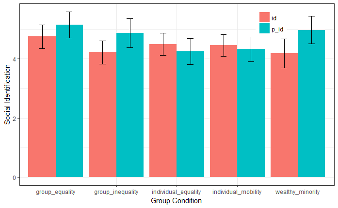

```r
id_all_lme.dat %>%
    group_by(group_condition, time) %>%
    summarise(mean_socid = mean(socid, na.rm = T),
              sd = sd(socid, na.rm = T),
              n= n(),
              ci = (sd/sqrt(n))*1.96) -> id_all_lme_mns.dat
ggplot(id_all_lme_mns.dat, aes(x = group_condition, y = mean_socid, fill = time)) +
    geom_bar(position=position_dodge(), stat="identity") +
    geom_errorbar(aes(ymin=mean_socid-ci, ymax=mean_socid+ci),
                  width=.2,                    # Width of the error bars
                  position=position_dodge(.9)) +
    theme_bw() +
    labs(x = "Group Condition", y = "Social Identification") +
    theme(legend.title = element_blank(),
          legend.position = c(0.80,0.90))
ggsave("Figure_group_by_socid_time.pdf")
```

```r
NA
```

Let’s build rough SEM to simplify analysis

# SEM socid simple

```r
# rename delta socid to make interp easier
# and make equality a factor
id_all.dat %<>% rename(socid_change = d_id) %>%
    mutate(equality_cond = factor(equality_cond),
           gameno = factor(gameno))
```

[output not shown]

There are some tough questions about dependencies between the variables. Let’s explore some of htese

# SEM socid simple

```r
    summary(socid_fit_5, fit.measures = TRUE)
```

```
lavaan 0.6-2 ended normally after 69 iterations

  Optimization method                           NLMINB
  Number of free parameters                         11

                                                  Used       Total
  Number of observations                            54          55

  Estimator                                         ML
  Model Fit Test Statistic                       2.111
  Degrees of freedom                                 3
  P-value (Chi-square)                           0.550

Model test baseline model:

  Minimum Function Test Statistic              107.842
  Degrees of freedom                                10
  P-value                                        0.000

User model versus baseline model:

  Comparative Fit Index (CFI)                    1.000
  Tucker-Lewis Index (TLI)                       1.030

Loglikelihood and Information Criteria:

  Loglikelihood user model (H0)                 81.108
  Loglikelihood unrestricted model (H1)         82.164

  Number of free parameters                         11
  Akaike (AIC)                                -140.217
  Bayesian (BIC)                              -118.338
  Sample-size adjusted Bayesian (BIC)         -152.897

Root Mean Square Error of Approximation:

  RMSEA                                          0.000
  90 Percent Confidence Interval          0.000  0.201
  P-value RMSEA <= 0.05                          0.604

```

[output cut: 20 more lines]

```
    start_tokens         -0.012    0.002   -5.490    0.000

Covariances:
                   Estimate  Std.Err  z-value  P(>|z|)
 .outgroup_aid ~~
   .ingroup_fvrtsm   -0.016    0.005   -3.502    0.000
 .socid_change ~~
   .token_change      0.007    0.004    1.570    0.116

Variances:
                   Estimate  Std.Err  z-value  P(>|z|)
   .socid_change      0.031    0.006    5.196    0.000
   .token_change      0.032    0.006    5.196    0.000
   .outgroup_aid      0.023    0.004    5.196    0.000
   .ingroup_fvrtsm    0.037    0.007    5.196    0.000
```